# UPS Sales Time Series Forecasting

Set the working directory and loading the data onto R for analysis.

Lets view the data to understand what it looks like

|  | Store | Dept | Date | Weekly_Sales | IsHoliday |
| --- | --- | --- | --- | --- | --- |
| 1 | 1 | 1 | 2/5/2010 | 24924.50 | FALSE |
| 2 | 1 | 1 | 2/12/2010 | 46039.49 | TRUE |
| 3 | 1 | 1 | 2/19/2010 | 41595.55 | FALSE |
| 4 | 1 | 1 | 2/26/2010 | 19403.54 | FALSE |
| 5 | 1 | 1 | 3/5/2010 | 21827.90 | FALSE |
| 6 | 1 | 1 | 3/12/2010 | 21043.39 | FALSE |

From the looks of the dataset, the store and department need to be factorized (currently stored as integers). The date variable needs to be converted to a date format for better analysis.

The IsHoliday variable represents whether the unit of analysis (that week in question) contained a holiday or not so that we may attribute increased sales if necessary.

Converting the department & store columns into categorical variables

```r
stores$Store = factor(stores$Store)
stores$Dept = factor(stores$Dept)
```

Change the date column which is currently considered as a factor into date format for our analysis.

Converting the binary variable IsHoliday into 0 / 1 instead of being represented as TRUE / FALSE for better analysis.

## Exploratory Data Analysis

Lets examine the descriptive statistics of the data.

```r
summary(stores)
```

```
     Store             Dept             Date             Weekly_Sales      IsHoliday
 13     : 10474   1      :  6435   Min.   :2010-02-05   Min.   : -4989   Min.   :0.00000
 10     : 10315   2      :  6435   1st Qu.:2010-10-08   1st Qu.:  2080   1st Qu.:0.00000
 4      : 10272   3      :  6435   Median :2011-06-17   Median :  7612   Median :0.00000
 1      : 10244   4      :  6435   Mean   :2011-06-18   Mean   : 15981   Mean   :0.07036
 2      : 10238   7      :  6435   3rd Qu.:2012-02-24   3rd Qu.: 20206   3rd Qu.:0.00000
 24     : 10228   8      :  6435   Max.   :2012-10-26   Max.   :693099   Max.   :1.00000
 (Other):359799   (Other):382960
```

Weekly sales has negative values as well. Could be because that particular store-department combination might have had more returns than purchases made by customers for the given unit of analysis.

Similarly the date ranges between Feb 2010 and Oct 2012.

In real life, we expect holidays to bring about more sales. Lets check if this assumption holds good by doing a Pearson correlation test.

```r
cor(stores$Weekly_Sales, stores$IsHoliday, use = "everything", method = "pearson")
```

```
[1] 0.01277422
```

Correlation co-efficient of 0.01 indicates that holidays do not necessarily affect the sales amount.

Plotting the weekly sales amounts

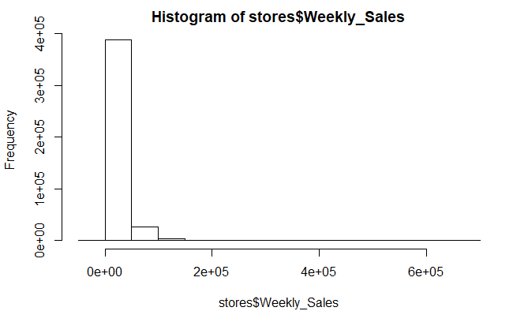

#### Loading the libraries needed for modelling

```r
library(forecast)
```

Dropping the IsHoliday column from the analysis since it need not be considered.

Filtering out Store 1, Department 1 to simplify analysis.

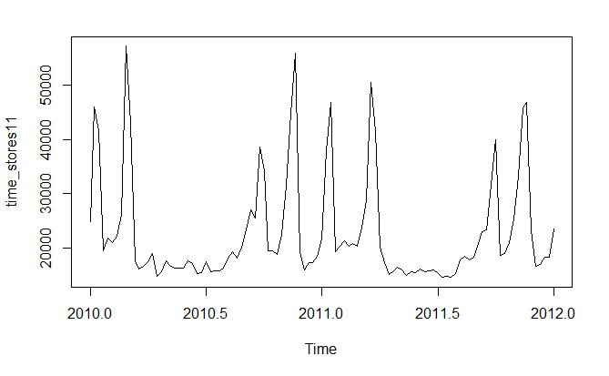

The time series appears to have spikes every now and then. There is no general trend of increase / decrease over the various weeks.

[output not shown]

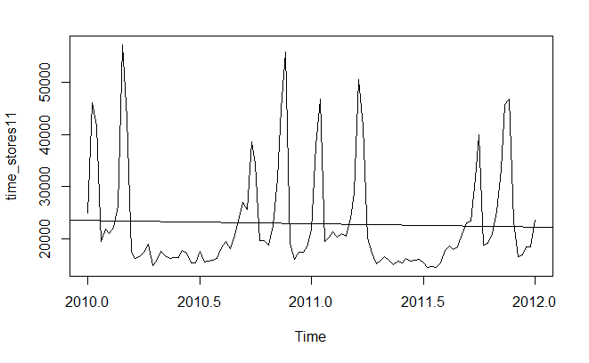

```r
plot(time_stores11)+abline(reg=lm(time_stores11~time(time_stores11)))
```

Trying to fit a linear line along the time series. Indicates a slight decrease over the various weeks of observation.

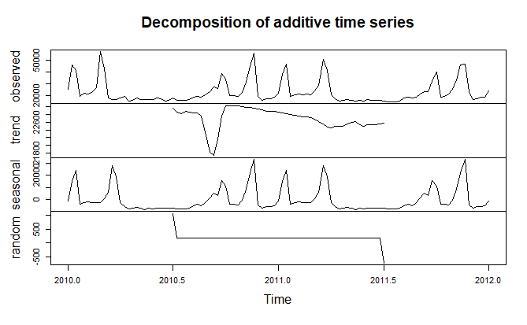

On decomposing the time series, we can see that the seasonal graph matches very closely with our observed data.

### Attempting to make the time series stationary by taking the log and differentiated log of the weekly amounts

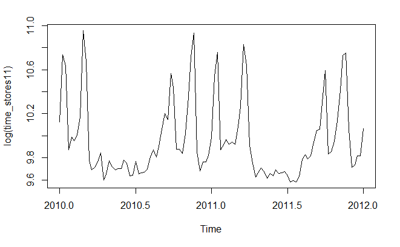

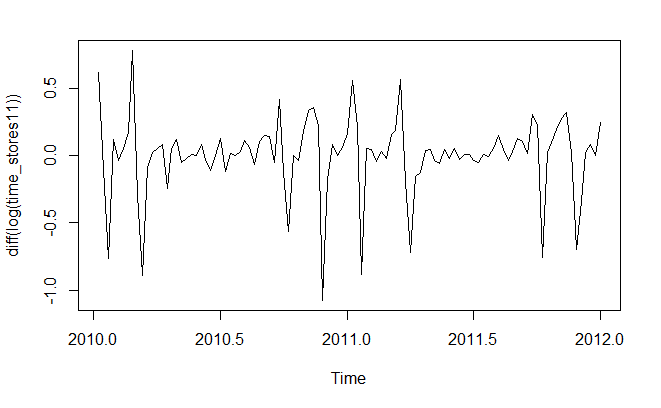

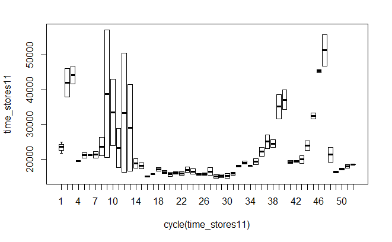

## Identify model parameters for estimation

```r
ts_store11_data <- ts(log(time_stores11),frequency = 52)
```

Calculate the autocorrelation function

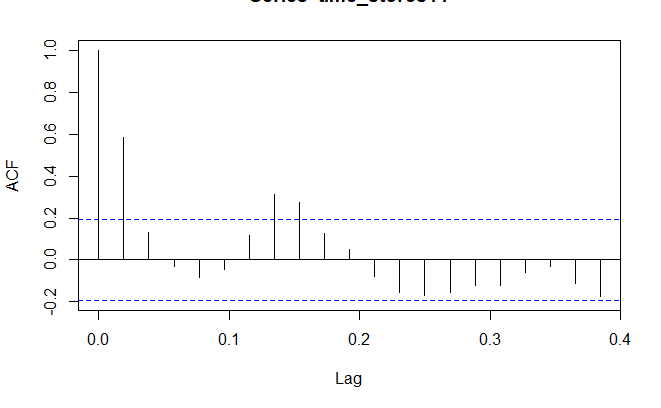

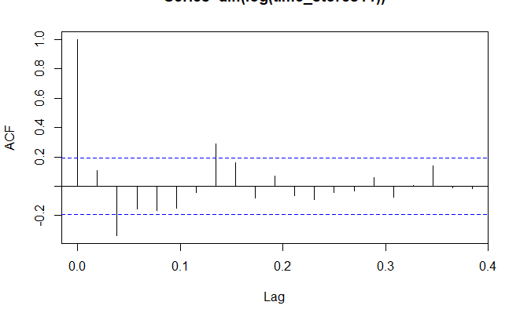

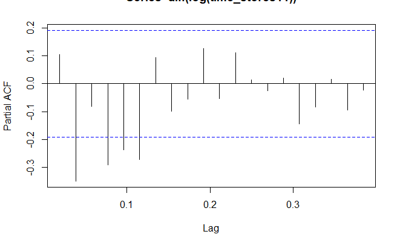

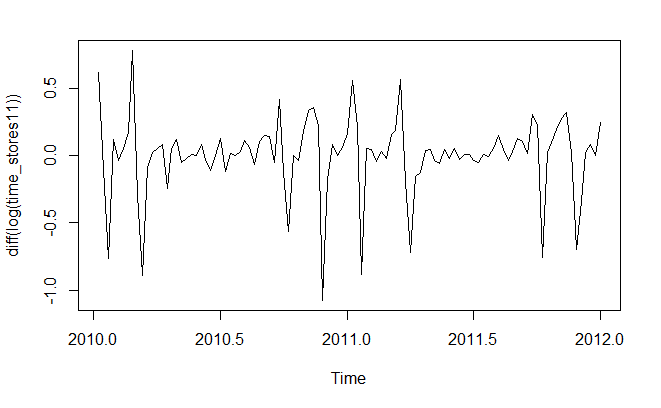

```r
fit
```

```
Call:
arima(x = log(time_stores11), order = c(0, 1, 1), seasonal = list(order = c(0,
    1, 1), period = 52))

Coefficients:
         ma1     sma1
      0.3677  -0.9828
s.e.  0.1353   3.5725

sigma^2 estimated as 0.03376:  log likelihood = -3.31,  aic = 12.63
```

Predict for next 4 weeks

```r
pred
```

```
$pred
Time Series:
Start = c(2012, 2)
End = c(2012, 5)
Frequency = 52
[1] 10.675421 10.730845  9.907877  9.991072

$se
Time Series:
Start = c(2012, 2)
End = c(2012, 5)
Frequency = 52
[1] 0.2264671 0.3800045 0.4873596 0.5750087
```

```r
pred1
```

```
Time Series:
Start = c(2012, 2)
End = c(2012, 5)
Frequency = 52
[1] 43231 45694 20067 21808
```

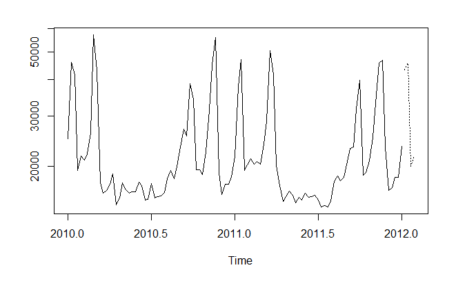